# An Introduction to Statistical Learning, Part 3: Linear Regression

Steven Troxler

December 20, 2015

Welcome to the third post in my series on [An Introduction to Statistical Learning with Applications in R](http://www-bcf.usc.edu/~gareth/ISL/). In the [last post](http://www.steventroxler.com/blog/?p=36) we looked at the bias-variance tradeoff for linear regression with a hand-coded regression function (which was also an introduction to R functions). In this post, we’ll follow along with the Chapter 3 lab in ISLR, and introduce the `lm` function, which R uses for linear regression.

At this point we are starting to trace the labs in ISLR. Two of the authors, Trevor Hastie and Rob Tibshirani, led a MOOC at Stanford going through their book. You can find links to all the materials, including videos of the labs, [here](http://www.r-bloggers.com/in-depth-introduction-to-machine-learning-in-15-hours-of-expert-videos/). The lectures and labs are quite good and I recommend them; these posts largely trace through the same material, although I’ve made some small changes and introduced some additional tools according to my tastes.

## The Boston dataset

In this lab, we’ll use the `Boston` dataset from the `MASS` library:

```r
boston <- MASS::Boston
names(boston)
```

```
#>  [1] "crim"    "zn"      "indus"   "chas"    "nox"     "rm"      "age"
#>  [8] "dis"     "rad"     "tax"     "ptratio" "black"   "lstat"   "medv"
```

This dataset measures a number of variable for different neighborhoods in Boston. The variable we’ll be looking at is `medv`, which is the median value of owner-occupied homes in $1000’s (how can you find that out? Type in `?MASS::Boston` at the R console). Let’s look at a density plot:

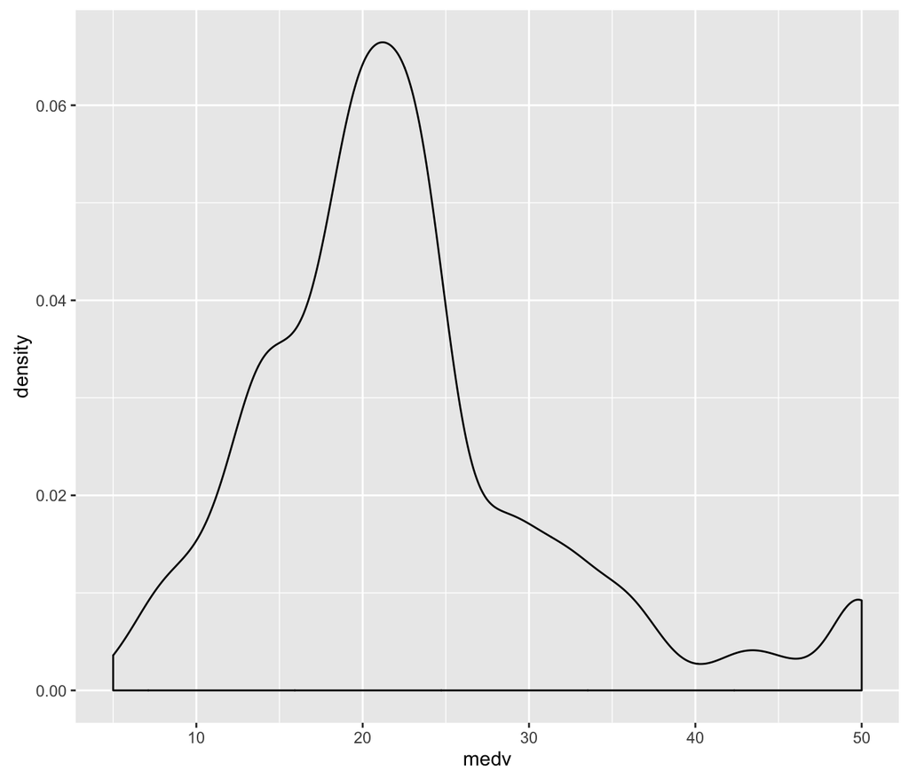

```r
ggplot(boston) + aes(x=medv) + geom_density()
```

## Simple linear regression: `medv` vs `lstat`

The `lstat` variables is the percentage of the neighborhood population which is “lower status” according to a model of socioeconomic status.

Let’s make a model for predicting `medv` from `lstat`. First, we should make a scatterplot

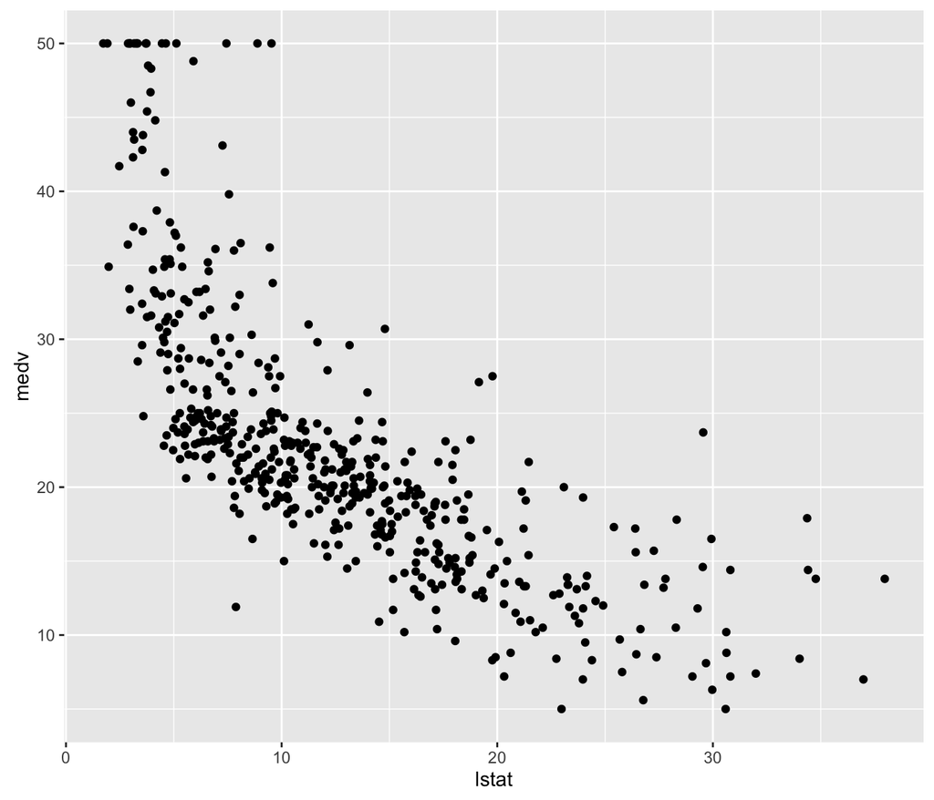

```r
p = ggplot(boston) + aes(x=lstat, y=medv) + geom_point()
p
```

It looks like the relationship here is probably nonlinear; in fact, there seems to be a curve. Since `lstat` is bounded below by 0, this isn’t surprising. We will proceed with a linear model in this section, and explore a nonlinear one later.

Also, there’s reason to question data quality: quite a few neighborhoods seem to hava a `medv` of 50, which is the maximum value. This seems unlikely to be correct; since this series is on statistical learning rather than data science we won’t pursue this further, but it’s possible that the data is *censored*, that is, that median household values higher than $50k were threshholded to $50k. This might affect our choice of model, if this were a serious study.

In R, we can fit a linear regression using the `lm` function:

```r
model0 <- lm(data=boston, medv ~ lstat)
```

The second entry of our call uses an R *formula*, which takes the form `y ~ x0 + x1 + ...`. This tells R to make a model where all of the `x` variables are used to predict `y`. In this case, we are using `lstat` to predict `medv`. We don’t explicitly say to include an intercept, but R does this automatically by default.

### Looking at regression statistics

Let’s take a look at the output using the `summary` function:

```r
summary(model0)
```

```
#>
#> Call:
#> lm(formula = medv ~ lstat, data = boston)
#>
#> Residuals:
#>     Min      1Q  Median      3Q     Max
#> -15.168  -3.990  -1.318   2.034  24.500
#>
#> Coefficients:
#>             Estimate Std. Error t value Pr(>|t|)
#> (Intercept) 34.55384    0.56263   61.41   <2e-16 ***
#> lstat       -0.95005    0.03873  -24.53   <2e-16 ***
#> ---
#> Signif. codes:  0 '***' 0.001 '**' 0.01 '*' 0.05 '.' 0.1 ' ' 1
#>
#> Residual standard error: 6.216 on 504 degrees of freedom
#> Multiple R-squared:  0.5441, Adjusted R-squared:  0.5432
#> F-statistic: 601.6 on 1 and 504 DF,  p-value: < 2.2e-16
```

There’s a lot of information here. If you read Chapter 3 of ISLR, they explain the output in detail, but the high points are: * The matrix of coefficients gives the value, standard error, `t` statistic value, and a `p`-value based on the `t` statistic. * These `p`-values indicate the probability of seeing a coefficient as large as we did, if the true coefficient were zero. We can use this as a measure of how likely it is that a variable is “important” for making predictions. * The `R-squared` statistic says the percentage of the variance in the `medv` variable which is explained by a linear relationship with `lstat`. This can often be used as a one-number summary of how well we fit the training data. * The `F-statistic` and its `p`-value are similar to the `t`-statistics, but they refer to the entire model rather than just one coefficient: the `p`-value is the probablility of seeing coefficients as large as we did, if in reality all of the coefficients were zero.

All of these probabilities are only approximate when the true errors around the best linear fit are not normal with constant variance, so we must always beware of taking them too seriously unless we’ve carefully validated the assumptions (which we have not here). Nonetheless, when a p-value is extremely small, in practice it means that the variables are almost certainly related.

We can get a confidence interval for each coefficient with `confint`:

```r
confint(model0)
```

```
#>                 2.5 %     97.5 %
#> (Intercept) 33.448457 35.6592247
#> lstat       -1.026148 -0.8739505
```

### Plotting the regression

We can look at a plot of the model in `ggplot2` by adding a `geom_abline`:

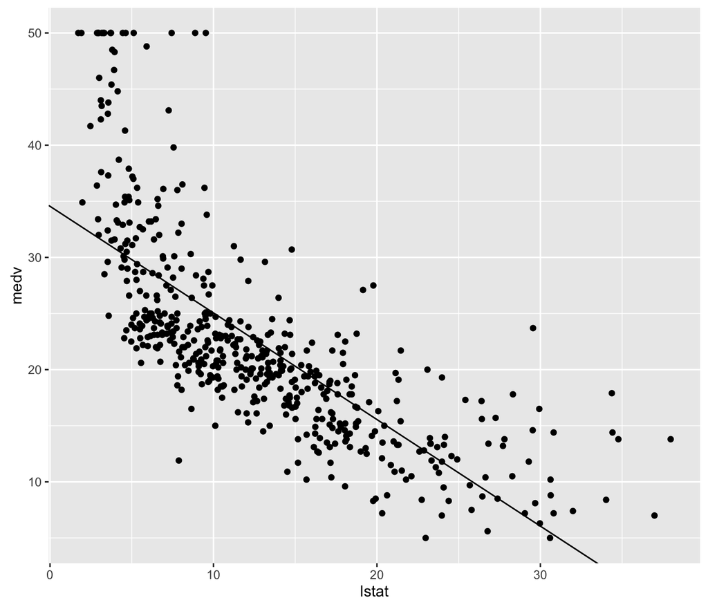

```r
p + geom_abline(aes(intercept = model0$coefficients[1], slope = model0$coefficients[2]))
```

or alternatively we could use `stat_smooth`, which uses `ggplot2`s own wrappper around `lm` and adds a confidence band around the line.

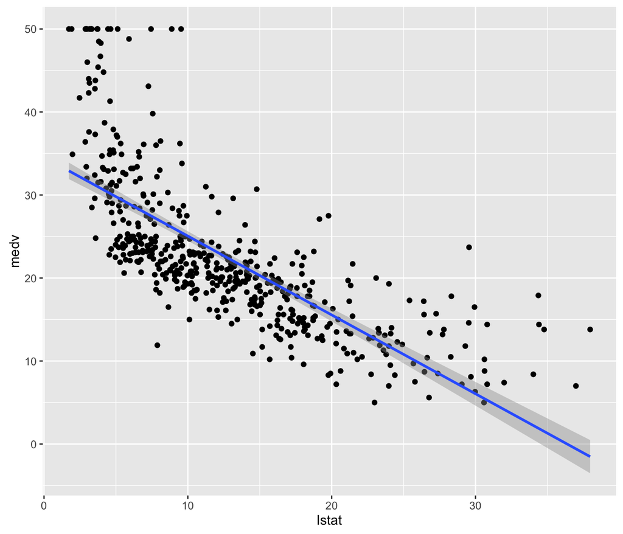

```r
p + stat_smooth(method='lm')
```

### Making predictions

To make a prediction, we can use R’s `predict` function. We first make a `data.frame` with new values of `lstat`, and then we can pass it to `predict`:

```r
new_data <- data.frame(lstat=c(10, 15, 20, 25))
predict(model0, new_data)
```

```
#>        1        2        3        4
#> 25.05335 20.30310 15.55285 10.80261
```

By adding `interval = "confidence"` argument, we can ask for a confidence interval as well as just a point estimate for each `x`:

```r
predict(model0, new_data, interval="confidence")
```

```
#>        fit       lwr      upr
#> 1 25.05335 24.474132 25.63256
#> 2 20.30310 19.731588 20.87461
#> 3 15.55285 14.773550 16.33216
#> 4 10.80261  9.717456 11.88776
```

## Adding a nonlinear term

### Making polynomial regression models

We’ve seen that the relationship between `medv` and `lstat` looks nonlinear. What happens if we add a quadratic term to the model?

```r
model1 <- lm(medv ~ lstat + (lstat ** 2), data = boston)
```

```r
model1 <- update(model1, ~ . + I(lstat ** 2))
```

```r
model1 <- lm(data = boston, medv ~ poly(lstat, 2))
```

which includes every lstat term of order up to `2` in the model.

### Looking at statistics

Let’s take a look:

```r
summary(model1)
```

```
#>
#> Call:
#> lm(formula = medv ~ poly(lstat, 2), data = boston)
#>
#> Residuals:
#>      Min       1Q   Median       3Q      Max
#> -15.2834  -3.8313  -0.5295   2.3095  25.4148
#>
#> Coefficients:
#>                  Estimate Std. Error t value Pr(>|t|)
#> (Intercept)       22.5328     0.2456   91.76   <2e-16 ***
#> poly(lstat, 2)1 -152.4595     5.5237  -27.60   <2e-16 ***
#> poly(lstat, 2)2   64.2272     5.5237   11.63   <2e-16 ***
#> ---
#> Signif. codes:  0 '***' 0.001 '**' 0.01 '*' 0.05 '.' 0.1 ' ' 1
#>
#> Residual standard error: 5.524 on 503 degrees of freedom
#> Multiple R-squared:  0.6407, Adjusted R-squared:  0.6393
#> F-statistic: 448.5 on 2 and 503 DF,  p-value: < 2.2e-16
```

We can compare nested models like these with the `anova` function, which uses F-statistics to ask whether there’s statistical evidence of a more complex model providing a better fit (although again, proper use of ANOVA in practice requires thinking carefully about model assumptions, which we have not done)

```r
anova(model0, model1)
```

```
#> Analysis of Variance Table
#>
#> Model 1: medv ~ lstat
#> Model 2: medv ~ poly(lstat, 2)
#>   Res.Df   RSS Df Sum of Sq     F    Pr(>F)
#> 1    504 19472
#> 2    503 15347  1    4125.1 135.2 < 2.2e-16 ***
#> ---
#> Signif. codes:  0 '***' 0.001 '**' 0.01 '*' 0.05 '.' 0.1 ' ' 1
```

Note that both the `t`-statistic of the `lstat ** 2` term in the summary and the `F` statistic indicate that the second-order term is strongly significant.

### Plotting a polynomial regression

There is no `geom` for adding a quadratic curve directly to a `ggplot2` plot, but we can set the formula used by `lm` in `stat_smooth` to add a plot of a polynomial regression to `ggplot`.

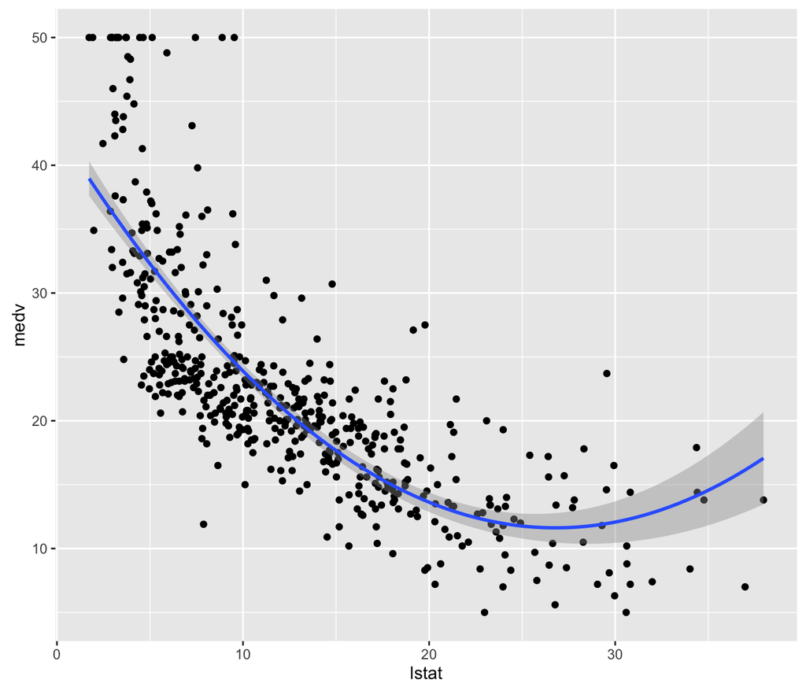

```r
p + stat_smooth(method='lm', formula = y ~ poly(x, 2))
```

Note that rather than `medv` and `lstat`, we use `y` and `x` in our formula. This is because when `ggplot2` delegates to `lm`, it uses its own copy of the `data.frame` we passed in, which has variables names according to aesthetics, rather than the original variable names.

## Multiple regression

Lets add `age`, which has the proportion of buildings built before 1940, to our model. We can add a different variable to a linear model, we can use the same types of commands we used to add the `lstat **2` term, one of the following:

```r
model2 <- lm(data=boston, medv ~ lstat + age)
model2 <- update(model0, ~ . + age)
```

As with the simple and quadratic regressions, we can look at statistics via `summary`:

```r
summary(model2)
```

```
#>
#> Call:
#> lm(formula = medv ~ lstat + age, data = boston)
#>
#> Residuals:
#>     Min      1Q  Median      3Q     Max
#> -15.981  -3.978  -1.283   1.968  23.158
#>
#> Coefficients:
#>             Estimate Std. Error t value Pr(>|t|)
#> (Intercept) 33.22276    0.73085  45.458  < 2e-16 ***
#> lstat       -1.03207    0.04819 -21.416  < 2e-16 ***
#> age          0.03454    0.01223   2.826  0.00491 **
#> ---
#> Signif. codes:  0 '***' 0.001 '**' 0.01 '*' 0.05 '.' 0.1 ' ' 1
#>
#> Residual standard error: 6.173 on 503 degrees of freedom
#> Multiple R-squared:  0.5513, Adjusted R-squared:  0.5495
#> F-statistic:   309 on 2 and 503 DF,  p-value: < 2.2e-16
```

```r
anova(model0, model1)
```

```
#> Analysis of Variance Table
#>
#> Model 1: medv ~ lstat
#> Model 2: medv ~ poly(lstat, 2)
#>   Res.Df   RSS Df Sum of Sq     F    Pr(>F)
#> 1    504 19472
#> 2    503 15347  1    4125.1 135.2 < 2.2e-16 ***
#> ---
#> Signif. codes:  0 '***' 0.001 '**' 0.01 '*' 0.05 '.' 0.1 ' ' 1
```

The `confint` and `predict` functions work just as they did for `model0`. Unfortunately, plotting multivariate regressions is tricky. With just two variables it’s possible to make a 3d perpective plot.

### Plotting multiple regression

Perhaps more useful, though, and also usable in higher dimensions, is a `coplot`:

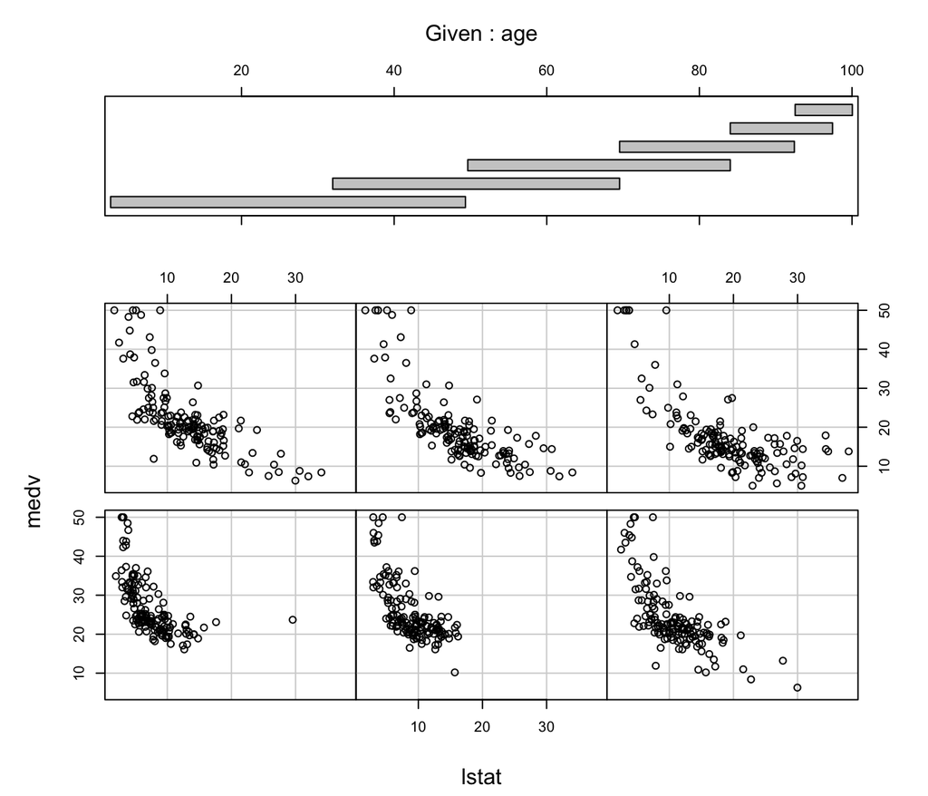

```r
coplot(medv ~ lstat | age, data=boston)
```

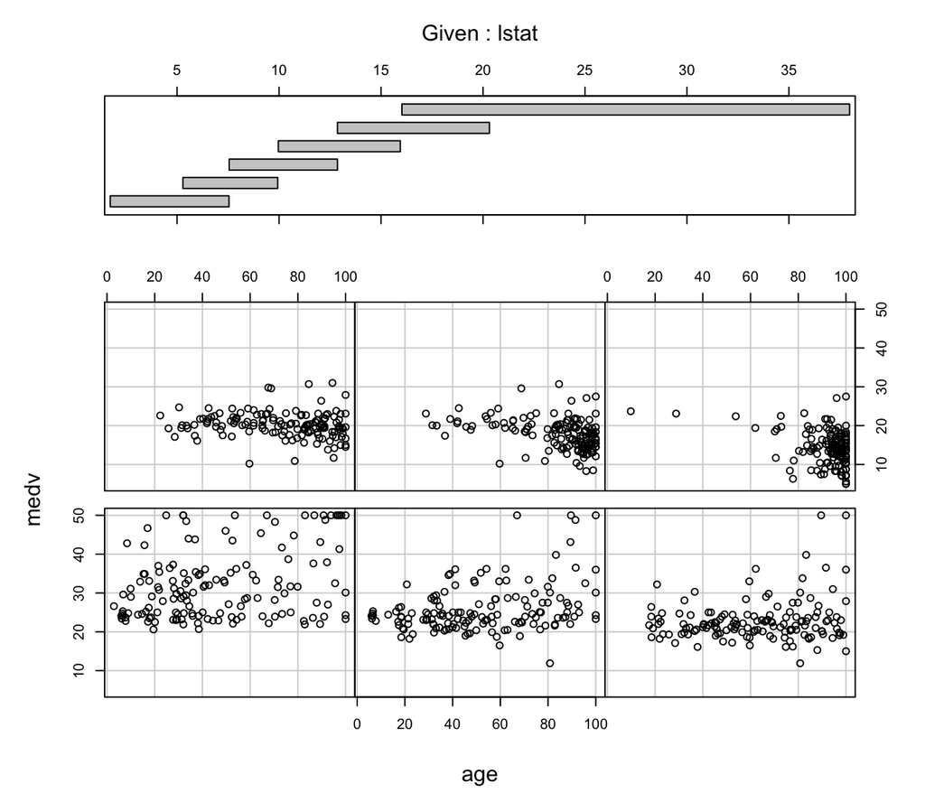

```r
coplot(medv ~ age | lstat, data=boston)
```

What `coplot` does is it breaks the data up into chunks based on the conditioning variable (to the right of the `|`), and makes a scatterplot for just that data.

It’s also possible to replace a `coplot` with a conditional plot in which the `y` variable is adjusted for the value of all other predictors. I hope to discuss this in a future blog post, after the ISLR series finishes.

## Diagnostic plots

An R `lm` output knows how to plot itself. When you call `plot` repeatedly on an `lm`, it runs through four different diagnostic plots. We can see all of them together if we first partition the plotting area:

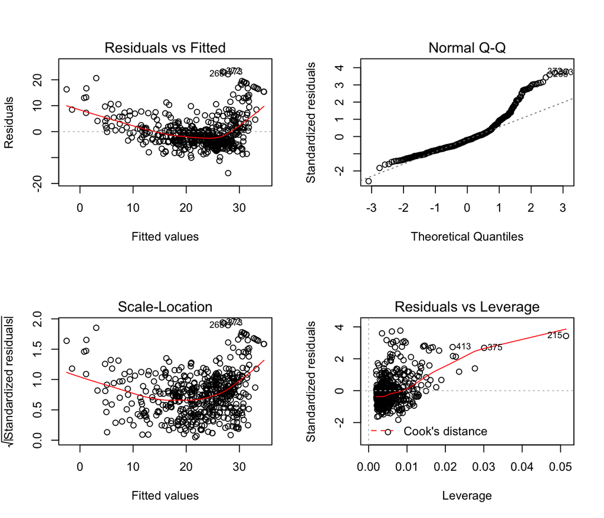

```r
par(mfrow=c(2, 2))
plot(model2)
```

These plots aren’t as nice as ggplot’s but they show a lot of information for little effort. Let’s break down what’s in them. The `Residuals vs Fitted` plot shows the errors on the training data as `y`, with the fitted value for `x`. Telltale signs to look for in this plot are: * increasing spread as the fitted value gets larger: this often means that we would do better using the log or square root of `y`. * Curveature in the plot, which usually means we are missing some nonlinearity.

Our plot of `model2` seems to show a bit of both of these features. The `Scale-Location` plot is very similar, except it plots the square root of the residuals. This is helpful for focusing on how their spread changes, without worrying about curveature.

The `Normal Q-Q` plot is a normal quantile plot. You can learn more about these in statistics courses, but basically when the data curves away from a straight line, it means the residuals don’t look normal. This means that unless your sample size is large, `p`-values using the `t` and `F` statistics may be misleading. We can see a clear curve here, indicating that our errors have a long right tail (which is very common, especially if a log model would be better).

The `Residuals vs Leverage` plot requires more knowledge to understand. But a high-leverage point is a point with unusual `x` values that cause it to get a lot of importance inside the regression model. When you have points that have large residuals and leverage both, it can mean that outliers have a lot of effect on your model. We see some high leverage points here, especially the one labeled `215` (which indicates which row of the data produced that point).

It’s possible to generate a marginal plot for one regressor (I’ll try to cover this in a future post), and in a two-variable model like this we can use perspective plots.

## Models with qualitative variables

We’ll close off with a quick look at running linear models with qualitative variables. For this, we’ll use the `Carseats` dataset from `ISLR`, which looks at carseat sales.

```r
carseats = tbl_df(ISLR::Carseats)
carseats
```

```
#> Source: local data frame [400 x 11]
#>
#>    Sales CompPrice Income Advertising Population Price ShelveLoc   Age
#>    (dbl)     (dbl)  (dbl)       (dbl)      (dbl) (dbl)    (fctr) (dbl)
#> 1   9.50       138     73          11        276   120       Bad    42
#> 2  11.22       111     48          16        260    83      Good    65
#> 3  10.06       113     35          10        269    80    Medium    59
#> 4   7.40       117    100           4        466    97    Medium    55
#> 5   4.15       141     64           3        340   128       Bad    38
#> 6  10.81       124    113          13        501    72       Bad    78
#> 7   6.63       115    105           0         45   108    Medium    71
#> 8  11.85       136     81          15        425   120      Good    67
#> 9   6.54       132    110           0        108   124    Medium    76
#> 10  4.69       132    113           0        131   124    Medium    76
#> ..   ...       ...    ...         ...        ...   ...       ...   ...
#> Variables not shown: Education (dbl), Urban (fctr), US (fctr)
```

We’ll make a model that includes the qualitative variable `ShelveLoc`, which gives the shelf location of the carseat. Creating a linear model with qualitative variables works the same as with quantitative variables in R:

```r
model3 <- lm(data = carseats, Sales ~ Advertising + ShelveLoc)
summary(model3)
```

```
#>
#> Call:
#> lm(formula = Sales ~ Advertising + ShelveLoc, data = carseats)
#>
#> Residuals:
#>     Min      1Q  Median      3Q     Max
#> -6.6480 -1.6198 -0.0476  1.5308  6.4098
#>
#> Coefficients:
#>                 Estimate Std. Error t value Pr(>|t|)
#> (Intercept)      4.89662    0.25207  19.426  < 2e-16 ***
#> Advertising      0.10071    0.01692   5.951 5.88e-09 ***
#> ShelveLocGood    4.57686    0.33479  13.671  < 2e-16 ***
#> ShelveLocMedium  1.75142    0.27475   6.375 5.11e-10 ***
#> ---
#> Signif. codes:  0 '***' 0.001 '**' 0.01 '*' 0.05 '.' 0.1 ' ' 1
#>
#> Residual standard error: 2.244 on 396 degrees of freedom
#> Multiple R-squared:  0.3733, Adjusted R-squared:  0.3685
#> F-statistic: 78.62 on 3 and 396 DF,  p-value: < 2.2e-16
```

Under the hood, linear models always use quantitative variables. R is converting our qualitative `ShelveLoc` variable into dummy variables behind the scenes. We can see the values of this dummy variable with the `contrasts` function:

```r
contrasts(carseats$ShelveLoc)
```

```
#>        Good Medium
#> Bad       0      0
#> Good      1      0
#> Medium    0      1
```

## Next Post

In the next post, we’ll look at a cousin of linear regression that works for classification, called *logistic regression*.